# capstone report

Tu Ha

July 14, 2018

# Machine Learning Engineer Nanodegree

## Capstone Project

Tu Ha  
July 09th, 2018

## I. Definition

### Project Overview

Time series forecasting is required in a lot of domains as weather forecast, earthquake prediction, finance forecast, or population forecast. Forecasting tasks help us to foresee disasters, risks or chances emerging from nature, social, financial system, etc. A plan or action is then established to overcome or reduce damages or take advantage of the chances. Generally the more dynamics the time series has, the harder to predict its outcome. Stock price time series is known to have pretty high dynamics. Forecasting stock price, particularly Apple stock, is therefore chosen in this project because Apple is a big name and a market development representative.

A lot of researches have been made to find methodologies and techniques to understand the time series data, and improve prediction performance. While the traditional methodology analyzes dynamics of the time series, and often eliminate some complicated dynamics within the series before do forecasting, the AI-based methodology tries to build a model which learns the dynamics of the time series as much as possible. In this project the traditional methodology is selected to forecast financial time series.

The exponential smoothing method is applied to forecast Apple stock price (AAPL). The previous proposal suggested applying forecasting techniques on the stock return instead of the price because managers are usually interested in the profit rather than the actual price. However identifying a proper return period is another problem which requires knowledge from other domains. This project keeps the original dynamics of the time series and tries to build several models to forecast the daily price.

### Problem Statement

The financial time series always have high dynamics and contain random variables. Forecasting these time series is a difficult task. It is necessary to understand the behaviour of the series to predict the future outcome. Moreover how to exploit this understanding to predict the future outcome is really a challenge. The dual problem is to find a model which could both explain the behavior of the series basing on data in the past, and predict pretty well the future outcome. This is the general problem which is one of the subject studied in the machine learning domain.

There are generally two methodologies to tackle this problem. The traditional way is analyzing the dynamics of the time series, and modeling each component as much as possible. The morden way uses artificial intelligence architectures to mimic the original dynamics. It is hard to say which methodology is dominant, and this project tries to apply the traditional methodology.

The dynamics of the Apple stock’s history price dataset in several quarters will be decomposed into trend, season, and error components. This analysis is reasonable because the stock price has the trend and seasonal structures. The analysis result provides clues to the intrinsic properties of the time series, which are helpful to build up a forecasting model by the exponential smoothing method. This modeling method results in various Error-Trend-Season (ETS) models which are supposed to be able to capture the hidden properties of the dataset. The model parameters are then tweaked to explain these dynamics components as much as possible. The ETS models together with their optimal parameters which forecast the future prices closest to most of the actual ones are the best models we are looking for.

### Metrics

There are several metrics to measure how well a model forecasts the future outcome, e.g. sum of squared errors (SSE), root mean squared error, mean absolute error, or mean absolute percentage error. SSE is calculated by the formula

$$SSE = \sum_{i=1}^{T} (observation_t - prediction_t)^2$$
in which $T$ is the current prediction period.

SSE is mostly used in many researches because the metric tends to degrade models which have large errors spontaneously. A model with similar errors sequence is generally prefered to the one whose errors are quite different in magnitude. The large difference of the predicted price compared to the actual one ususally brings in huge risks. SSE metric will magnify these abnormal errors and makes the total squared error become very large.

In addition to that, the forecasting ETS models in this project happenly explain a dataset most when the sum of squared errors is minimal. If parameters of a model are somehow optimized so that the model adapts most to the dataset, the metric becomes the indicator of the capability of the model. This provides a tool to select which ETS models are best for the AAPL time series in a specific period of time. The SSE metric is therefore used in this project to look for optimal parameters, and evaluate performance of models.

Another metric is used in this project to measure the similarity between two curves. The following figures present the idea about the similarity. The drift between similar curves is very small in the right one, and the shapes of two curves are also quite the same. The two curves are shifted in parts by several offsets only. The left figure shows the non-similarity where drift is present clearly.

Non-similar curves

Similar curves

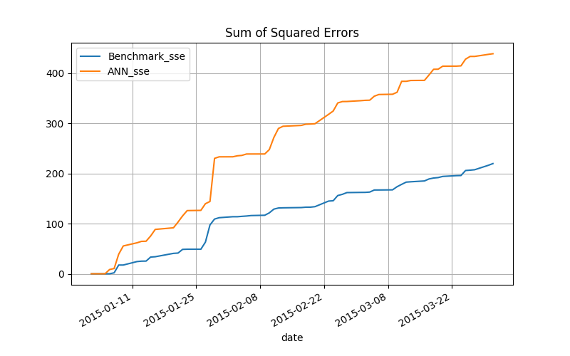

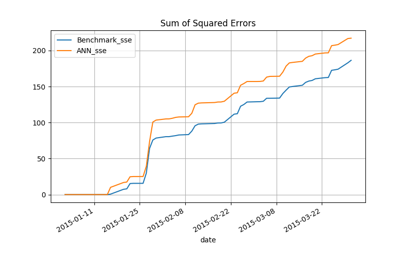

The similarity can be calculated by the difference between the gradients of the two curves. The smaller the value, the more similar they are. Because this metric is applied to measure the similarity of two SSE curves, the gradient is the squared error at each prediction period. Similarity is then defined as the Sum of all Errors between the two Squared Errors of two curves.

$$SESE = \sum_{i=1}^{T} (observation_t^a - prediction_t^a)^2 - (observation_t^b - prediction_t^b)^2$$

where $observation_t^a$ is the observation of the curve $a$ at the period $t$.